# Companies Survival Analysis Report

Abeer Gaber

2025-05-07

## 0.1 Enough Falling – It’s Time to Rise

Some will recognize these names—companies that were once very famous and lasted for years.

What happened to them? Why did they stop? Why couldn’t they keep going?

If you want to avoid the same fate, this report is for you.

It analyzes financial performance, stock trends, and employee data across many companies to identify patterns of survival and closure.

By understanding the traits of both successful and failed companies, I provide actionable insights and strategies to help you avoid failure and thrive in a competitive market.

# 1 Data Overview

```
## 'data.frame':    733 obs. of  20 variables:
##  $ Company_ID       : int  1 1 1 1 1 1 1 1 1 1 ...
##  $ Company_Name     : chr  "Rite Aid" "Rite Aid" "Rite Aid" "Rite Aid" ...
##  $ Foundation_Year  : int  1962 1962 1962 1962 1962 1962 1962 1962 1962 1962 ...
##  $ Closing_Year     : int  2023 2023 2023 2023 2023 2023 2023 2023 2023 2023 ...
##  $ Dynamic_Duration : int  61 61 61 61 61 61 61 61 61 61 ...
##  $ Industries       : chr  "Retail Stores" "Retail Stores" "Retail Stores" "Retail Stores" ...
##  $ Status           : chr  "Defunct" "Defunct" "Defunct" "Defunct" ...
##  $ Current_Status   : chr  "Re_Opened" "Re_Opened" "Re_Opened" "Re_Opened" ...
##  $ Notes            : chr  "Bankruptcy protection 2023" "Bankruptcy protection 2023" "Bankruptcy protection 2023" "Bankruptcy protection 2023" ...
##  $ Years            : int  2023 2022 2021 2020 2019 2018 2017 2016 2015 2014 ...
##  $ Employee_Number  : int  47000 53000 50000 48000 51000 59000 87000 88000 89000 89000 ...
##  $ Revenue          : num  24092 24568 24043 21928 21640 ...
##  $ Net_Income       : num  -750 -538 -91 -452 -422 ...
##  $ Assets           : num  7527 8529 9335 9452 7591 ...
##  $ long_Term_Debt   : num  2938 2748 3080 3097 3479 ...
##  $ Total_Liabilities: num  8169 8430 8720 8778 6405 ...
##  $ Holders_Equity   : num  -642 99 615 675 1187 ...
##  $ Avg_Stock_Price  : num  2.14 6.74 16.98 13.24 9.5 ...
##  $ Avg_TTM_Net_EPS  : num  -20.2 -13.54 -1.98 -7.57 -9.52 ...
##  $ Avg_PE_Ratio     : num  -0.11 -0.5 -8.58 -1.75 -1 ...
```

```
##    Company_ID    Company_Name       Foundation_Year  Closing_Year
##  Min.   : 1.00   Length:733         Min.   :1858    Min.   :   0.0
##  1st Qu.:17.00   Class :character   1st Qu.:1911    1st Qu.:   0.0
##  Median :39.00   Mode  :character   Median :1962    Median :   0.0
##  Mean   :36.01                      Mean   :1950    Mean   : 483.8
##  3rd Qu.:53.00                      3rd Qu.:1984    3rd Qu.:   0.0
##  Max.   :69.00                      Max.   :2015    Max.   :2024.0
##  Dynamic_Duration  Industries           Status          Current_Status
##  Min.   :  4.0    Length:733         Length:733         Length:733
##  1st Qu.: 39.0    Class :character   Class :character   Class :character
##  Median : 61.0    Mode  :character   Mode  :character   Mode  :character
##  Mean   : 72.4
##  3rd Qu.:112.0
##  Max.   :167.0
##     Notes               Years      Employee_Number      Revenue
##  Length:733         Min.   :1995   Min.   :      0   Min.   :        0
##  Class :character   1st Qu.:2012   1st Qu.:    170   1st Qu.:     1320
##  Mode  :character   Median :2017   Median :  24400   Median :    14953
##                     Mean   :2016   Mean   : 129964   Mean   :  1868226
##                     3rd Qu.:2021   3rd Qu.: 157900   3rd Qu.:    87470
##                     Max.   :2025   Max.   :2300000   Max.   :302000000
##    Net_Income           Assets          long_Term_Debt     Total_Liabilities
##  Min.   :  -23800   Min.   :        0   Min.   :       0   Min.   :        0
##  1st Qu.:       0   1st Qu.:     2329   1st Qu.:      96   1st Qu.:     1371
##  Median :     336   Median :    16402   Median :    3365   Median :    11610
##  Mean   :  254746   Mean   :  3215790   Mean   :  335885   Mean   :  1059887
##  3rd Qu.:    4572   3rd Qu.:   136295   3rd Qu.:   19012   3rd Qu.:   103470
##  Max.   :54730018   Max.   :515000000   Max.   :44522000   Max.   :122000000
##  Holders_Equity      Avg_Stock_Price   Avg_TTM_Net_EPS     Avg_PE_Ratio
##  Min.   :  -552000   Min.   :   0.00   Min.   :-547.000   Min.   :-239.33
##  1st Qu.:      411   1st Qu.:   0.00   1st Qu.:   0.000   1st Qu.:   0.00
##  Median :     4657   Median :  15.51   Median :   0.450   Median :   6.70
##  Mean   :  2109194   Mean   :  47.67   Mean   :  -0.251   Mean   :  13.51
##  3rd Qu.:    33230   3rd Qu.:  46.12   3rd Qu.:   2.990   3rd Qu.:  14.96
##  Max.   :392000000   Max.   :1007.67   Max.   :  39.600   Max.   : 758.00
```

| Company_ID | Company_Name | Foundation_Year | Closing_Year | Dynamic_Duration | Industries | Status | Current_Status | Notes | Years | Employee_Number | Revenue | Net_Income | Assets | long_Term_Debt | Total_Liabilities | Holders_Equity | Avg_Stock_Price | Avg_TTM_Net_EPS | Avg_PE_Ratio |
| --- | --- | --- | --- | --- | --- | --- | --- | --- | --- | --- | --- | --- | --- | --- | --- | --- | --- | --- | --- |
| 1 | Rite Aid | 1962 | 2023 | 61 | Retail Stores | Defunct | Re_Opened | Bankruptcy protection 2023 | 2023 | 47000 | 24092 | -750 | 7527 | 2938 | 8169 | -642 | 2.14 | -20.20 | -0.11 |
| 1 | Rite Aid | 1962 | 2023 | 61 | Retail Stores | Defunct | Re_Opened | Bankruptcy protection 2023 | 2022 | 53000 | 24568 | -538 | 8529 | 2748 | 8430 | 99 | 6.74 | -13.54 | -0.50 |
| 1 | Rite Aid | 1962 | 2023 | 61 | Retail Stores | Defunct | Re_Opened | Bankruptcy protection 2023 | 2021 | 50000 | 24043 | -91 | 9335 | 3080 | 8720 | 615 | 16.98 | -1.98 | -8.58 |
| 1 | Rite Aid | 1962 | 2023 | 61 | Retail Stores | Defunct | Re_Opened | Bankruptcy protection 2023 | 2020 | 48000 | 21928 | -452 | 9452 | 3097 | 8778 | 675 | 13.24 | -7.57 | -1.75 |
| 1 | Rite Aid | 1962 | 2023 | 61 | Retail Stores | Defunct | Re_Opened | Bankruptcy protection 2023 | 2019 | 51000 | 21640 | -422 | 7591 | 3479 | 6405 | 1187 | 9.50 | -9.52 | -1.00 |
| 1 | Rite Aid | 1962 | 2023 | 61 | Retail Stores | Defunct | Re_Opened | Bankruptcy protection 2023 | 2018 | 59000 | 21529 | 943 | 8989 | 3371 | 7388 | 1601 | 30.25 | 16.65 | 1.82 |

## 1.1 📊 Company Status: Who Survived and Who Didn’t

**Insight:**  
This visualizations shows various distributions of companies by their status—whether they are still operational or have closed.

# 2 Company Lifespan by Status

[figure not shown]

## 2.1 Company Lifespan by Industry

## 2.2 Warnings:

1. **Large Outliers:**
   - Pay attention to companies that fall at the extremes of the chart, as these may represent exceptional cases of very long or short lifespans. These outliers could indicate extraordinary circumstances or significant fluctuations in performance.
2. **Variability Across Industries:**
   - Some industries show significant variation in company lifespans. This variation may be due to factors like market changes or a sudden drop in demand for products or services, which calls for companies in these industries to review their strategies to ensure sustainability.
3. **Data Limitations:**
   - The analysis does not account for external factors that may influence company lifespans, such as economic fluctuations or technological changes. These factors should be considered when developing growth strategies.
4. **Geographical and Cultural Differences:**
   - The lifespan of companies within the same industry can vary based on location or cultural practices. Business owners should consider the local context when evaluating lifespan expectations for their companies.

## 2.3 Insights:

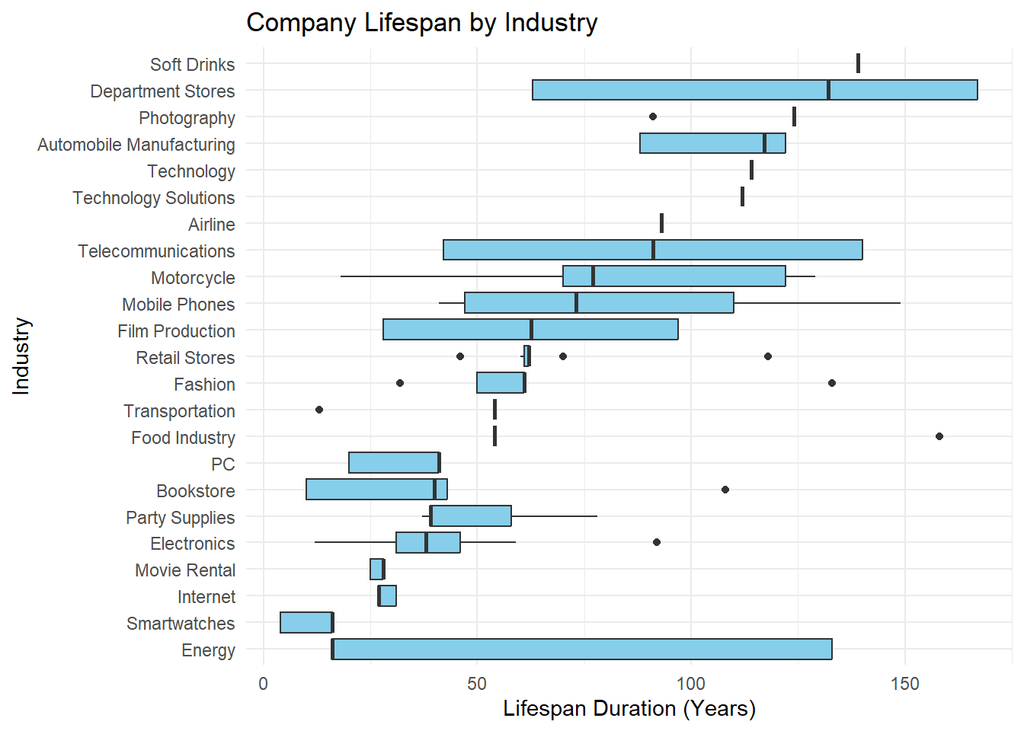

**Actionable Takeaway:**  
If your company is in the closure group, it is essential to analyze the contributing factors and take immediate action to turn the trend around.

**Actionable Takeaway:**  
A company’s ability to extend its lifespan depends on factors like financial management, adaptability, and market positioning. If your company is near the lower end of the lifespan spectrum, it is crucial to reassess its strategies, focusing on long-term sustainability rather than short-term gains.

## 2.4 Employee Count: Employee Distribution by Company Status

Employee count is another factor that can help determine company success. A significant drop in employee numbers is often seen in companies that are in decline. Companies that are growing or stable tend to have a steady increase in their employee base. Let’s look at how the number of employees varies based on company status.

# 3 Data Summary for Employee Count

```
##  int [1:733] 47000 53000 50000 48000 51000 59000 87000 88000 89000 89000 ...
```

```
##    Min. 1st Qu.  Median    Mean 3rd Qu.    Max.
##       0     170   24400  129964  157900 2300000
```

```
## [1] 0
```

# 4 Employee Count Distribution by Company Status

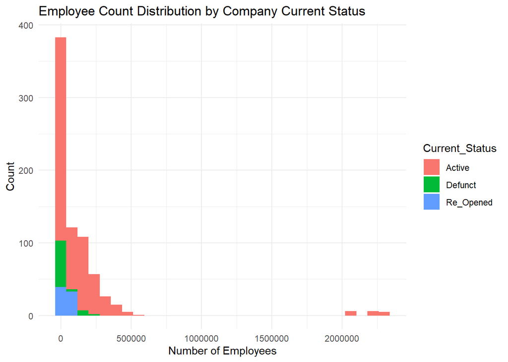

## 4.1 📈 Revenue Over Time

Revenue is a key indicator of a company’s financial performance. Companies that have closed often show erratic or decreasing revenue trends, while active companies tend to have more stable or growing revenues. Let’s explore how revenue varies across companies based on their status (active vs. defunct).

**Actionable Takeaway:**  
If your revenue is showing a decline or significant fluctuation, it is a red flag. To avoid closure, consider analyzing the reasons behind these revenue drops—such as market shifts, cost inefficiencies, or competition—and make adjustments like cost-cutting, diversifying product lines, or improving marketing efforts.

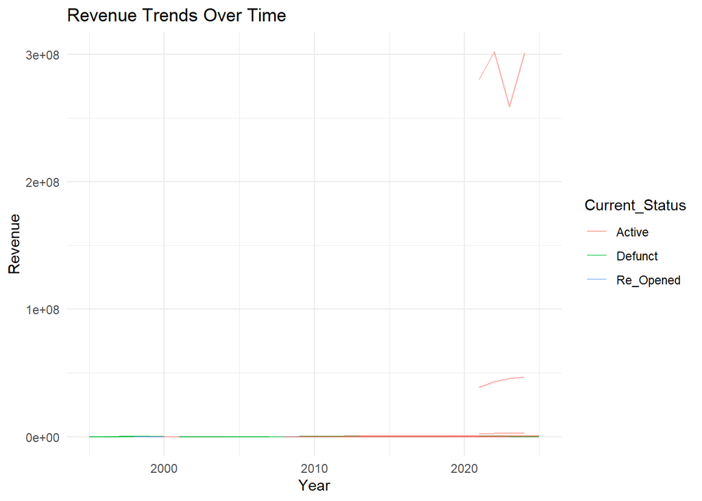

```
##
## Call:
## lm(formula = Revenue ~ Years, data = companiesSurvival)
##
## Residuals:
##       Min        1Q    Median        3Q       Max
##  -4454418  -3239525  -1924449   -517776 298452750
##
## Coefficients:
##               Estimate Std. Error t value Pr(>|t|)
## (Intercept) -607883933  261749510  -2.322   0.0205 *
## Years           302389     129807   2.330   0.0201 *
## ---
## Signif. codes:  0 '***' 0.001 '**' 0.01 '*' 0.05 '.' 0.1 ' ' 1
##
## Residual standard error: 21250000 on 731 degrees of freedom
## Multiple R-squared:  0.007369,   Adjusted R-squared:  0.006011
## F-statistic: 5.427 on 1 and 731 DF,  p-value: 0.0201
```

### 4.1.1 Predict future revenue

```
##   Years predicted_revenue
## 1  2025           4454418
## 2  2026           4756807
## 3  2027           5059197
## 4  2028           5361586
```

## 4.2 Average Revenue and Net Income by Industry

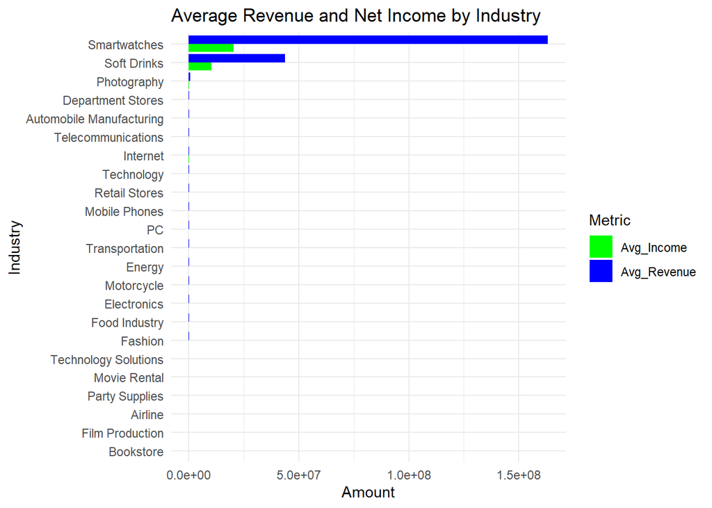

# 5 Net Income vs. Revenue

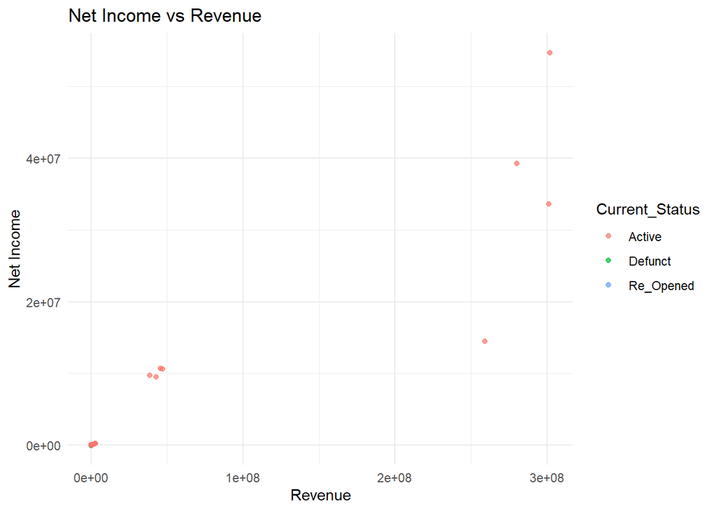

## 5.1 Prediction Model: Forecasting Future Company Status

Let’s build a predictive model using the data to identify which companies are more likely to continue, and which ones might be closed.

```
## Confusion Matrix and Statistics
##
##           Reference
## Prediction Active Defunct
##    Active     117       0
##    Defunct      0      15
##
##                Accuracy : 1
##                  95% CI : (0.9724, 1)
##     No Information Rate : 0.8864
##     P-Value [Acc > NIR] : 1.216e-07
##
##                   Kappa : 1
##
##  Mcnemar's Test P-Value : NA
##
##             Sensitivity : 1.0000
##             Specificity : 1.0000
##          Pos Pred Value : 1.0000
##          Neg Pred Value : 1.0000
##              Prevalence : 0.8864
##          Detection Rate : 0.8864
##    Detection Prevalence : 0.8864
##       Balanced Accuracy : 1.0000
##
##        'Positive' Class : Active
##
```

## 5.2 Feature Importance

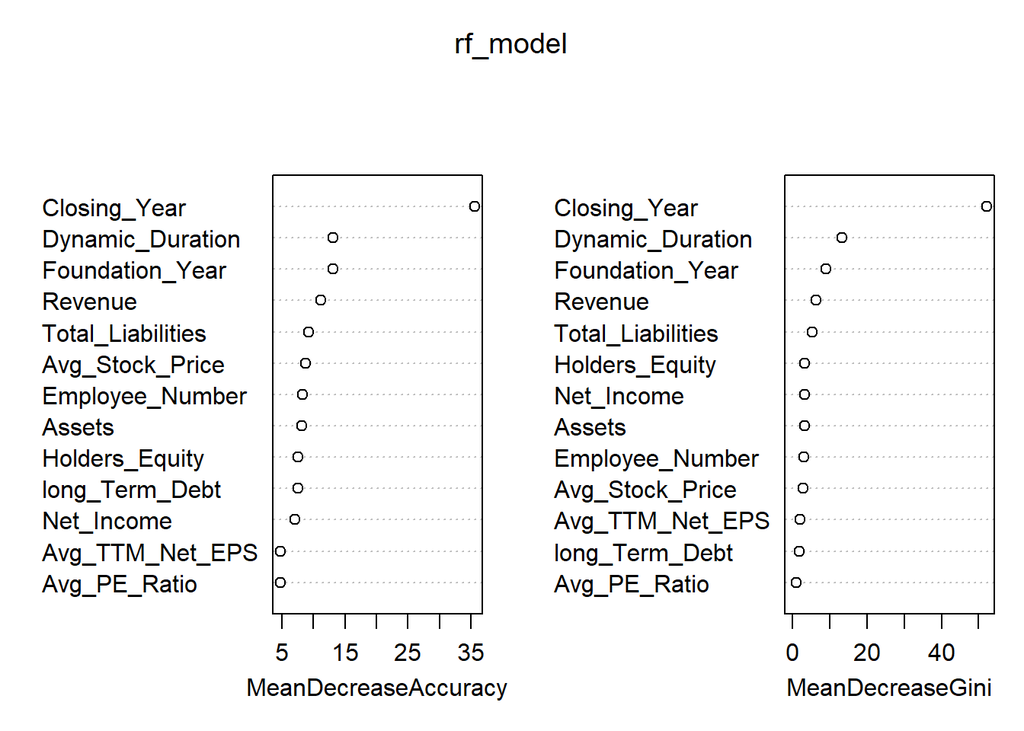

## 5.3 Industry-Specific Insights

### 5.3.1 Company Status by Industry

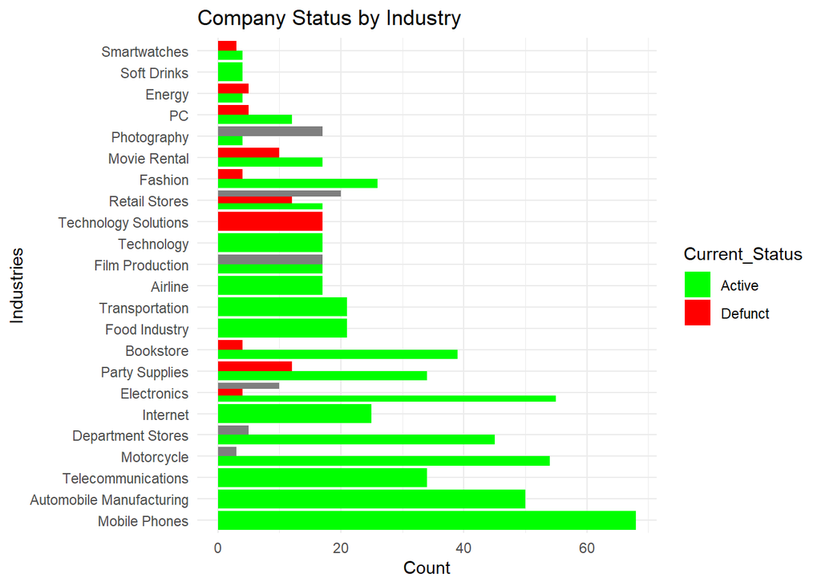

## 5.4 ⚠️ Critical Warning for At-Risk Companies

**You are not out of time yet—but you’re close:**

- Take this prediction seriously:
- Reassess your business model.
- Cut non-essential costs.
- Innovate your offerings.
- Rebuild trust with investors and employees.

The next move you make could decide your company’s fate. Delay is the most dangerous option.

## 5.5 💰 Stock Price and PE Ratio

**Actionable Takeaway:**  
A low PE ratio can indicate that your company is undervalued or struggling. To boost the PE ratio, consider improving profitability by increasing revenue, reducing costs, or communicating your company’s growth potential more effectively to investors.

# 6 Average PE Ratio by Status

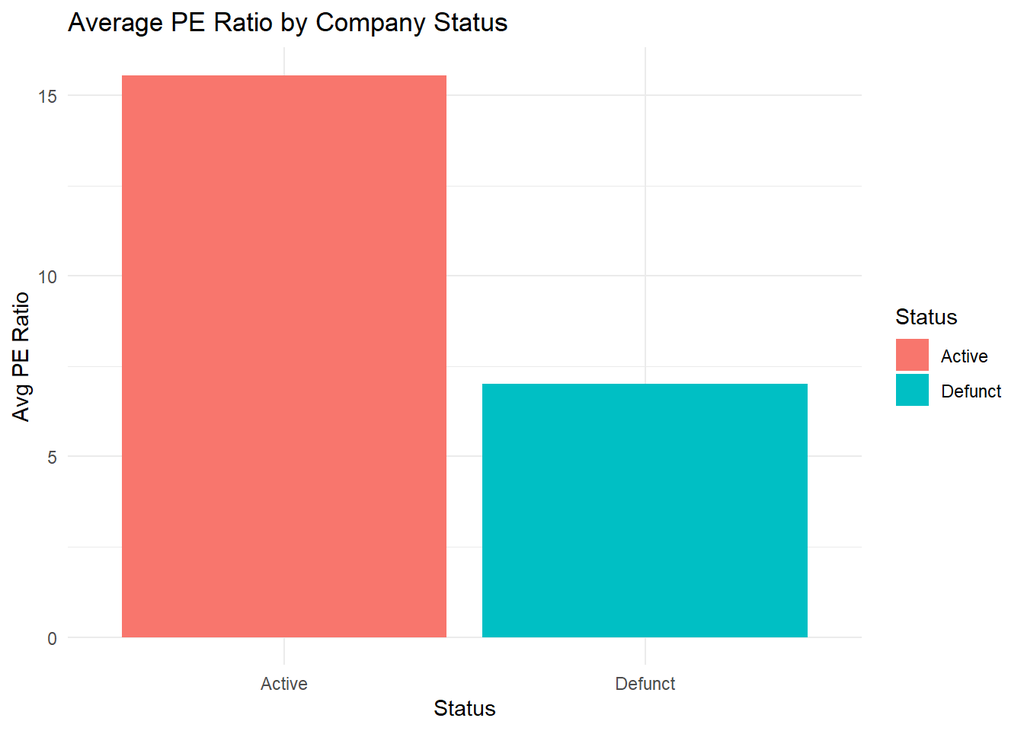

# 7 Average Stock Price Distribution

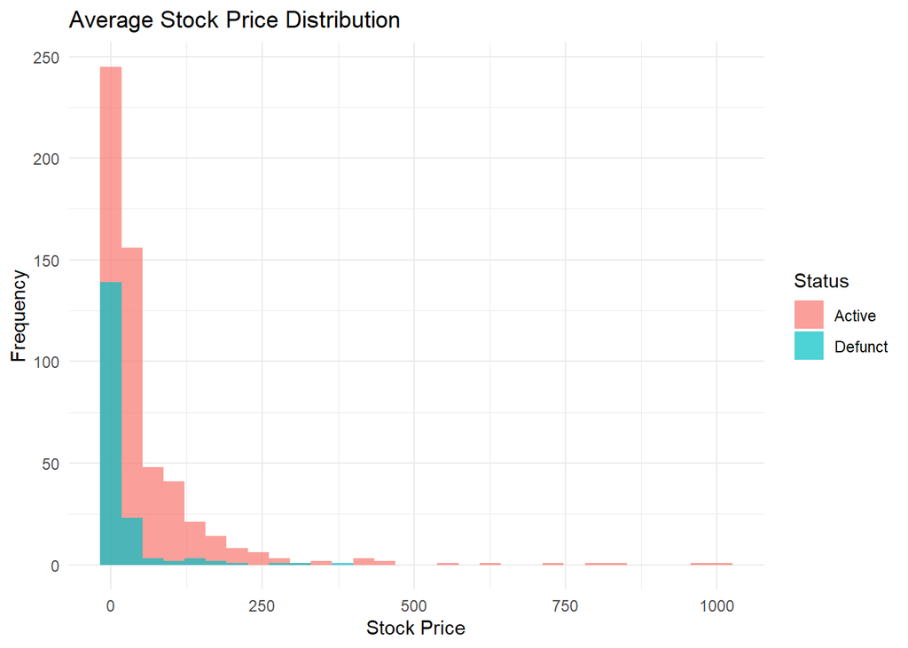

# 8 Company-Level Summaries

|  | Company_Name | Status | Avg_Revenue | Avg_Net_Income | Avg_Stock_Price | Avg_PE |
| --- | --- | --- | --- | --- | --- | --- |
| 1 | Abercrombie &amp; Fitch | Active | 4159.9475 | 0 | 0 | 0 |
| 2 | Alaska Airlines | Active | 6161.294117647059 | 335.2941176470588 | 43.64529411764706 | 21.96470588235294 |
| 3 | Alphabet (Google) | Active | 138352.5 | 32850 | 0 | 0 |
| 4 | Amscan | Active | 0 | 10.54333333333333 | 0 | 0 |
| 5 | Apple | Active | 219995.8235294118 | 51252.58823529412 | 74.01941176470588 | 17.57529411764706 |
| 6 | At&amp;T | Active | 131048.4705882353 | 11048.64705882353 | 15.38 | 9.570588235294117 |
| 7 | Atari | Defunct | 16125 | -14675 | 0 | 0 |
| 8 | Barnes &amp; Noble Education | Active | 1620.692307692308 | -46.84615384615385 | 348.0838461538461 | 6.131538461538462 |
| 9 | BlackBerry | Active | 5590.235294117647 | -54.23529411764706 | 15.60235294117647 | -14.44882352941177 |
| 10 | Blockbuster | Defunct | 0.324 | -589.64 | 0 | 0 |

[output cut: 59 more lines]

# 9 8.1 Key Takeaways and Survival Strategies

## 9.1 1. Financial Health:

- Regularly monitor key financial metrics (e.g., revenue, profit margins, debt) to identify signs of distress early. Financial health is crucial for making proactive adjustments before issues escalate into crises.
- **Tip:** Set up automated financial alerts to track deviations from key performance indicators (KPIs).

## 9.2 2. Customer Focus:

- Reassess your customer needs and the value you’re offering. Adapt to shifting market demands and invest in customer loyalty. Focus on enhancing the customer experience and responding to feedback.
- **Tip:** Leverage customer surveys and feedback loops to stay aligned with market demands.

## 9.3 3. Case Study:

- **Apple** successfully navigated financial and market crises by embracing new technologies such as touchscreen interfaces and app ecosystems. These innovations drastically improved product appeal, operational efficiency, and customer engagement.
- In contrast, **BlackBerry** failed to adapt to changing consumer demands and technological trends, holding on to outdated features like physical keyboards and enterprise-focused software. As a result, Apple thrived, while BlackBerry’s market share collapsed.
- **Insight:** Technology and customer preferences evolve quickly; companies must stay agile to meet these changes.

## 9.4 4. Lesson Learned:

- Companies that proactively adopt relevant technologies and innovate based on market needs are more likely to survive and grow. Those that resist change or fail to anticipate shifts in consumer behavior risk becoming obsolete.
- **Action Point:** Regularly assess emerging technologies and industry trends to remain competitive.

## 9.5 5. Investor Confidence:

- If your PE ratio is low, focus on improving profitability and clearly communicating your vision for growth to investors. Transparency about future strategies and clear milestones can help rebuild investor confidence.
- **Tip:** Develop a clear roadmap of your company’s growth and communicate this regularly to your investors to build trust.

## 9.6 6. Operational Efficiency:

- Short lifespans and closures often result from poor management or operational inefficiencies. Regular audits of operations, cost-control measures, and continuous innovation can prevent stagnation and ensure long-term success.
- **Action Point:** Implement Lean or Six Sigma practices to streamline processes and eliminate waste.

## 9.7 7. Adaptability:

- The ability to pivot or adapt to market conditions is essential for long-term survival. Companies that failed typically couldn’t adapt quickly enough to external changes like technology shifts, regulatory changes, or market demands.
- **Tip:** Build a culture of flexibility within your organization, ensuring your team is prepared to react swiftly to market changes.

# 10 8.2 Industry-Specific Insights: Most Affected by Closures

## 10.1 1. Industries Most Affected by Company Closures:

- Some industries are more vulnerable to closures due to rapid technological changes, shifts in consumer behavior, and economic disruptions. These industries often experience a higher number of business failures due to their inability to adapt to external changes.
- **Retail Industry:**
  - Retail has seen a significant number of closures in recent years, especially brick-and-mortar stores, as consumer preferences shift towards online shopping. Companies that fail to invest in e-commerce or adopt omni-channel strategies risk closure.
- **Technology Industry:**
  - The fast pace of technological innovation poses both opportunities and threats. Startups and even established companies can be wiped out if they fail to innovate or keep up with new technologies, like the rise of mobile apps, AI, or cloud computing.
- **Hospitality and Travel:**
  - The hospitality and travel sectors are highly vulnerable to external factors such as economic downturns, pandemics, and geopolitical instability. The COVID-19 pandemic, for example, led to massive closures in this industry.
- **Manufacturing Industry:**
  - In some regions, the manufacturing industry has seen closures due to automation, shifting labor costs, and competition from low-cost countries. Companies that fail to innovate and adopt efficient technologies face an increased risk of shutting down.

## 10.3 3. Lessons for Business Owners in Affected Industries:

- **Adapting to Market Shifts:**
  - Industries prone to closures need to stay agile and adapt quickly to market shifts, whether they’re technological advancements, changing customer preferences, or external crises. The key is to continuously innovate and stay ahead of the competition.
- **Diversification:**
  - For industries with high closure rates, diversifying revenue streams and exploring new markets can be critical. Companies should consider expanding their offerings or targeting new customer segments to reduce reliance on a single market.
- **Technology Adoption:**
  - Industries like retail, technology, and manufacturing can significantly benefit from adopting the latest technologies. Automation, e-commerce platforms, and AI can help streamline operations and enhance customer experience, reducing the risk of closure.

### 10.3.1 Conclusion:

In conclusion, analyzing financial performance, customer needs, technological trends, and operational efficiency provides valuable insights into a company’s potential for survival or closure. Proactive monitoring of these factors, combined with a willingness to adapt and innovate, can significantly increase a company’s chances of thriving in a competitive and ever-changing marketplace. By making strategic decisions based on these insights, business owners can avoid closure and secure long-term success.